```python
from IPython.display import HTML

HTML('''<script>
code_show=true;
function code_toggle() {
 if (code_show){
 $('div.input').hide();
 } else {
 $('div.input').show();
 }
 code_show = !code_show
}
$( document ).ready(code_toggle);
</script>
The raw code for this IPython notebook is by default hidden for easier reading.
To toggle on/off the raw code, click <a href="javascript:code_toggle()">here</a>.''')
```

The raw code for this IPython notebook is by default hidden for easier reading. To toggle on/off the raw code, click here.

# Project 3: Wrangle OpenStreetMap Data

1. Map Area
2. Problems Encountered in the Map
3. Data Overview
4. Additional Ideas
5. Conclusion

## Map Area

New York City, New York

- http://www.openstreetmap.org/relation/175905
- I chose NYC because of its great diversity in cultures, art, food, shops, and people. Working on this dataset will help me discover more interesting aspects about my city.

By taking a systematic sample of elements from the original region, the OSM data used in this project was reduced to 80 MB.

## Problems Encountered in the Map

After running a portion of the sampled data against a set of testing process, I noticed several challenges in the data wrangling process. I'll address each of the problems in the following project.

- Inconsistancy in the street names and abbreviations (Ave/ave/Avenue)
- Inconsistancy in zipcodes ('NY 10023'/'10023')
- Different geoinfo systems (TIGER, Nycdoitt, gnis)
- Some entries have unique attributes according to their functions ('building', 'height')
- The timestamp for each entry cannot be parsed directly in MongoDB('2013-05-07T18:35:26Z')

#### Inconsistant Street Names

- Street/St/st: By auditing the street names using regex name matching, we see that for each type of street name, there are several alternations with either upper/lower case or abbreviation. We'll choose one form and modify the rest.
- 'A', 'K', 'O': Instances of single letters are from the alphabetical names of several streets in Manhattan and Brooklyn. We'll reverse the word order and change them into 'A Avenue', 'O Avenue', etc. to keep it consistant.
- '1', '10', '1603': The numbers are route names in the Highway system. There are not many of them, so we'll ignore these instances.
- 'Broadwat': Typos will be corrected.

```python
import xml.etree.ElementTree as ET
from collections import defaultdict
from collections import Counter
import codecs
import json
import pprint
import re

osm_file = open("new_york_sample.osm", "r")

street_type_re = re.compile(r'\S+\.?$', re.IGNORECASE)
freq = defaultdict(int)

def print_sorted_dict(d):
    keys = d.keys()
    keys = sorted(keys, key=lambda s: s.lower())
    for k in keys:
        v = d[k]
        print "%s: %d" % (k, v)

def count_street_types(osmfile):
    """Count the occurance of each street type"""
    for event, elem in ET.iterparse(osmfile):
        if (elem.tag == "tag") and (elem.attrib['k'] == "addr:street"):
            m = street_type_re.search(elem.attrib['v'])
            if m:
                street_type = m.group()
                freq[street_type] += 1
    return print_sorted_dict(freq)

count_street_types(osm_file)
```

[output not shown]

```python
# Modify the street names and save it to attribute v

osm_file = "new_york_sample.osm"
street_type_re = re.compile(r'\b\S+\.?$', re.IGNORECASE)


mapping = {"Ave": "Avenue",
           "ave": "Avenue",
           "avenue": "Avenue",
           "Broadwat": "Broadway",
           "CIRCLE": "Circle",
           "DRIVE": "Drive",
           "drive": "Drive",
           "LANE": "Lane",
           "Rd": "Road",
           "ROAD": "Road",
           "St": "Street",
           "St.": "Street"
            }

def update_name(name, mapping):
    """
    Change according to the mapping above
    Modify all the alphabet avenues
    Original:
            'Avenue L'
    Returns:
            'L Avenue'
    """

    old = name.split(' ')[-1]
    keep = name.split(' ')[:-1]
    new = []
    if old in mapping.keys():
        new.append(mapping[old])
        return ' '.join(keep + new)
    elif keep == ['Avenue']:
        return ' '.join(re.findall("\S+", name)[::-1])
    else:
        return name


def change_street_names(element):
    if (element.tag == "tag") and (element.attrib['k'] == "addr:street"):
        element.attrib['v'] = update_name(element.attrib['v'], mapping)
        return element.attrib['v']
```

Below is an example of the changes made to the street names(using the sample_sample.osm file to limit the output size). It's taken from a lecture assignment at this [link](https://classroom.udacity.com/nanodegrees/nd002/parts/0021345404/modules/316820862075462/lessons/768058569/concepts/8653197080923#).

```python
expected = ["Street", "Avenue", "Boulevard", "Drive", "Court",
            "Place", "Square", "Lane", "Road", "Trail", "Parkway",
            "Walk", "Circle"]

def audit_street_type(street_types, street_name):
    m = street_type_re.search(street_name)
    if m:
        street_type = m.group()
        if street_type not in expected:
            street_types[street_type].add(street_name)

def is_street_name(elem):
    return (elem.attrib['k'] == "addr:street")

def audit(osmfile):
    osm_file = open(osmfile, "r")
    street_types = defaultdict(set)
    for event, elem in ET.iterparse(osm_file, events=("start",)):

        if elem.tag == "node" or elem.tag == "way":
            for tag in elem.iter("tag"):
                if is_street_name(tag):
                    audit_street_type(street_types, tag.attrib['v'])
    osm_file.close()
    return street_types


def clean_names(osmfile):
    """Show the changes in street names"""
    st_types = audit(osmfile)
    pprint.pprint({key:value for key,value in st_types.items()[0:3]})

    for st_type, ways in st_types.iteritems():
        for name in ways:
            better_name = update_name(name, mapping)
            print ''.join(name+" => "+better_name)

clean_names('sample_sample.osm')
```

```
{'L': set(['Avenue L']),
 'Park': set(['Edgewater Park']),
 'Plaza': set(['Newkirk Plaza'])}
Newkirk Plaza => Newkirk Plaza
Edgewater Park => Edgewater Park
Avenue L => L Avenue
Washington St => Washington Street
Rolling Hill Green => Rolling Hill Green
Union Turnpike => Union Turnpike
Avenue U => U Avenue
Park Drive East => Park Drive East
Erika Loop => Erika Loop
```

#### Inconsistant Zip Codes

```python
clean_postal = re.compile(r'^(\d{5})')
new = re.compile(r'^\D*(\d{5})')

def change_zip_code(element):
    """
    Remove all the State abbreviations in zip codes
    Original:
            'NY 11023'
    Return:
            '11023'
    """

    if element.tag == 'way' or element.tag == 'node':
        for sub in element:
            if sub.get('k') == 'addr:postcode':
                new_zip = new.match(sub.attrib['v'])
                zip_codes = clean_postal.match(sub.attrib['v'])
                if new_zip:
                    if zip_codes:
                        if sub.attrib['v'] not in zip_codes.group():
                            sub.attrib['v'] = new.match(sub.attrib['v']).group(1)
                    else:
                        sub.attrib['v'] = new.match(sub.attrib['v']).group(1)
                        print sub.attrib['v']
```

#### Unparseable Datetime

- The 'timestamp' attribute for entries is in the form: 'yyyy-mm-dd T hh:mm:ss Z'. To use this info directly in MongoDB, we'll modify them into parseable forms.
- Since we are only intersted in the year, we'll just keep the year of the timestamp.

```python
import datetime, dateutil.parser

def change_timestamp(elem):
    """
    Find and keep only the year of each timestamp
    Original:
            '2016-07-25T17:17:46Z'
    Return:
            '2016'
    """

    if elem.tag == "node" or elem.tag == "way":
        for att in elem.attrib.keys():
            if att == 'timestamp':
                d = dateutil.parser.parse(elem.attrib['timestamp'])
                year = int(d.strftime('%Y'))
                elem.attrib['timestamp'] = int(year)
```

#### Different Geo Encoding Systems and Unique Attributes

- 'TIGER': There are different geoinformatic systems including TIGER, Nycdoitt, and gnis. We'll conclude them into seperate dictionary items
- 'leisure': Some tags have unique attributes such as 'source', 'height', 'ele', etc., we'll create seperate dictionary keys for these tags

```python
lower = re.compile(r'^([a-z]|_)*$')
lower_colon = re.compile(r'^([a-z]|_)*:([a-z]|_)*$')
problemchars = re.compile(r'[=\+/&<>;\'"\?%#$@\,\. \t\r\n]')

CREATED = ["version", "changeset", "timestamp", "user", "uid"]

def shape_element(elem):
    """
    Form a node for each entry
    Organize different types of info into dict format
    """

    node = {}
    created = {}
    address ={}

    if elem.tag == "node" or elem.tag == "way":
        for att in elem.attrib.keys():
            node['type'] = elem.tag

            # Create sub-dict 'created' within node
            if att in CREATED:
                created[att] = elem.attrib[att]
                node['created'] = created

            # Create list 'pos' within dict 'created'
            elif elem.attrib[att] == elem.get('lat') or elem.get('lon'):
                pos = []
                pos.append(float(elem.get('lat')))
                pos.append(float(elem.get('lon')))
                node['pos'] = pos

            # Add other items into node, such as 'id', 'visible', etc.
            else:
                node[att] = elem.attrib[att]

        for sub in elem:
            if sub.tag == 'tag':
                # Ignore all problematic characters
                if problemchars.search(sub.get('k')):
                    pass

                # Ignore the tags that have colons after 'addr:'
                elif sub.get('k').startswith('addr:'):
                    if lower_colon.search(sub.get('k')[5:]):
                        pass

                    # Add all the arributes of 'addr:' into dict
                    else:
                        address[sub.get('k')[5:]] = sub.get('v')
                        node['address'] = address

                # Add other series of tags into dict
                # In nyc there are tiger, nycdoitt, and gnis systems
                elif lower_colon.search(sub.get('k')):
                    title = sub.get('k').split(':')[0]
                    node[title] = {}
                    node[title][sub.get('k').split(':')[-1]] = sub.get('v')

                # Add other individual tags such as 'building', 'ele'
                # 'height' for buildings,'sport', 'source' for 'leisure'
                else:
                    node[sub.get('k')] = sub.get('v')

            # Add node references
            elif sub.tag == 'nd':
                refs = []
                refs.append(sub.get('ref'))
                node['node_refs'] = refs

        return node
```

#### Make Changes And Create JSON File

```python
def process_map(file_in, pretty = False):

    file_out = "new_york_sample_output.json"
    data = []
    with codecs.open(file_out, "w") as output:
        for _, element in ET.iterparse(file_in):

            # Update street names in 'v' attributes
            change_street_names(element)

            # Modify problematic zip codes
            change_zip_code(element)

            # Modify timestamps into parseable forms
            change_timestamp(element)

            # Organize attributes and format the dataset
            elem = shape_element(element)

            if elem:
                data.append(elem)
                if pretty:
                    output.write(json.dumps(elem, indent=2)+"\n")
                else:
                    output.write(json.dumps(elem) + "\n")

    return "Process completed!"
```

```python
process_map('new_york_sample.osm', pretty = False)
```

```
'Process completed!'
```

## Data Overview

**File Sizes**

- new_york_sample.osm ............ 80 MB
- new_york_output.json .... 69.1 MB

**Number of documents**

> db.project.find().count()  
> 368247

**Number of nodes**

> db.project.find({"type":"node"}).count()  
> 316575

**Number of ways**

> db.project.find({"type":"way"}).count()  
> 51653

**Number of unique users**

> db.project.distinct("created.user").length  
> 1542

#### Top 1 contributing user

```python
from pymongo import MongoClient
client = MongoClient('mongodb://localhost:27017/')
db = client.nycosm

pipeline = [{"$group": {"_id": "$created.user",
                        "count": {"$sum": 1}}},
            {"$sort": {"count": -1}},
            {"$limit": 1}]
for a in db.project.aggregate(pipeline):
    print a
```

```
{u'count': 162931, u'_id': u'Rub21_nycbuildings'}
```

#### Number of users appearing only once

```python
pipeline = [{"$group": {"_id": "$created.user",
                        "count": {"$sum": 1}}},
            {"$group": {"_id": "$count",
                         "num_users": {"$sum": 1}}},
            {"$sort": {"_id": 1}},
            {"$limit": 1}]
for a in db.project.aggregate(pipeline):
    print a
```

```
{u'num_users': 557, u'_id': 1}
```

## Additional Ideas

### Development of OpenStreetMap

#### How many entries were added to New York OSM each year?

```python
pipeline = [{"$group": {"_id": "$created.timestamp",
                        "count": {"$sum": 1}}},
            {"$sort": {"_id": 1}}]

# Number of entries each year, ordered by time
year = []
count = []

for num_entry in db.project.aggregate(pipeline):
    print num_entry
    year.append(str(num_entry['_id']))
    count.append(num_entry['count'])
```

```
{u'count': 192, u'_id': 2007}
{u'count': 661, u'_id': 2008}
{u'count': 33227, u'_id': 2009}
{u'count': 5731, u'_id': 2010}
{u'count': 3116, u'_id': 2011}
{u'count': 6002, u'_id': 2012}
{u'count': 134334, u'_id': 2013}
{u'count': 125721, u'_id': 2014}
{u'count': 19835, u'_id': 2015}
{u'count': 39428, u'_id': 2016}
```

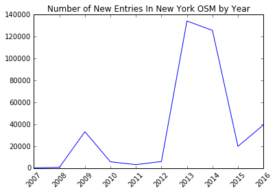

```python
import matplotlib.pyplot as plt
import numpy as np
%matplotlib inline

x = np.array(range(10))
y = np.array(count)
x_ticks = plt.xticks(x, year, rotation=45)
plt.plot(x, y)
plt.title('Number of New Entries In New York OSM by Year')
plt.show()
```

OpenStreetMap originally started in 2004 in the United Kingdom. We can see from the graph that not until the year of 2007 did the map start to develop in New York, United States.

### User Contribution

#### 1. Who are the top 10 contributors?

```python
pipeline = [{"$group": {"_id": "$created.user",
                        "count": {"$sum": 1}}},
            {"$sort": {"count": -1}},
            {"$limit": 10}]
users = []
for user in db.project.aggregate(pipeline):
    print user
    users.append(user['_id'])
```

```
{u'count': 162931, u'_id': u'Rub21_nycbuildings'}
{u'count': 31246, u'_id': u'ingalls_nycbuildings'}
{u'count': 21068, u'_id': u'woodpeck_fixbot'}
{u'count': 14508, u'_id': u'minewman'}
{u'count': 9090, u'_id': u'ediyes_nycbuildings'}
{u'count': 7793, u'_id': u'lxbarth_nycbuildings'}
{u'count': 7427, u'_id': u'NJDataUploads'}
{u'count': 7362, u'_id': u'smlevine'}
{u'count': 6362, u'_id': u'ingalls'}
{u'count': 5719, u'_id': u'CoreyFarwell'}
```

#### 2. How much of the data was entered by top 10 contributors?

```python
top10 = db.project.find({"created.user": {"$in": users}}).count()
total = db.project.find().count()
top10/float(total)
```

```
0.7427243127574699
```

### Local Amenities

#### 1. What are the top 10 amenities in the mapping area?

```python
pipeline = [{"$match": {"amenity": {"$exists": 1}}},
            {"$group": {"_id": "$amenity",
                        "count": {"$sum": 1}}},
            {"$sort": {"count": -1}},
            {"$limit": 10}]

for a in db.project.aggregate(pipeline):
    print a
```

```
{u'count': 235, u'_id': u'parking'}
{u'count': 164, u'_id': u'bicycle_parking'}
{u'count': 157, u'_id': u'school'}
{u'count': 156, u'_id': u'place_of_worship'}
{u'count': 122, u'_id': u'restaurant'}
{u'count': 34, u'_id': u'fast_food'}
{u'count': 28, u'_id': u'cafe'}
{u'count': 23, u'_id': u'fire_station'}
{u'count': 22, u'_id': u'fuel'}
{u'count': 18, u'_id': u'bench'}
```

#### 2. Among the recorded restaurants, what are the top 10 cuisines?

```python
pipeline = [{"$match": {"cuisine": {"$exists": 1}}},
            {"$group": {"_id": "$cuisine",
                        "count": {"$sum": 1}}},
            {"$sort": {"count": -1}},
            {"$limit": 10}]
for cuisine in db.project.aggregate(pipeline):
    print cuisine
```

```
{u'count': 12, u'_id': u'american'}
{u'count': 11, u'_id': u'italian'}
{u'count': 11, u'_id': u'coffee_shop'}
{u'count': 10, u'_id': u'pizza'}
{u'count': 7, u'_id': u'burger'}
{u'count': 5, u'_id': u'chinese'}
{u'count': 5, u'_id': u'mexican'}
{u'count': 4, u'_id': u'sandwich'}
{u'count': 3, u'_id': u'french'}
{u'count': 3, u'_id': u'japanese'}
```

#### 3. Among all the places of worship, what are the existing religions?

```python
pipeline = [{"$match": {"amenity": "place_of_worship"}},
            {"$group": {"_id": "$religion",
                        "count": {"$sum": 1}}},
            {"$sort": {"count": -1}}]
for religion in db.project.aggregate(pipeline):
    print religion
```

```
{u'count': 135, u'_id': u'christian'}
{u'count': 13, u'_id': u'jewish'}
{u'count': 6, u'_id': None}
{u'count': 1, u'_id': u'muslim'}
{u'count': 1, u'_id': u'sikh'}
```

#### 4. What are the main denominations of Christian churches?

```python
pipeline = [{"$match": {"religion": "christian"}},
            {"$group": {"_id": "$denomination",
                        "count": {"$sum": 1}}},
            {"$sort": {"count": -1}},
            {"$limit": 10}]
for denomination in db.project.aggregate(pipeline):
    print denomination
```

```
{u'count': 60, u'_id': None}
{u'count': 18, u'_id': u'baptist'}
{u'count': 11, u'_id': u'catholic'}
{u'count': 10, u'_id': u'methodist'}
{u'count': 8, u'_id': u'presbyterian'}
{u'count': 8, u'_id': u'lutheran'}
{u'count': 5, u'_id': u'pentecostal'}
{u'count': 3, u'_id': u'orthodox'}
{u'count': 3, u'_id': u'episcopal'}
{u'count': 2, u'_id': u'roman_catholic'}
```

### Leisures

#### 1. What are the main places of leisure within the mapping area?

```python
pipeline = [{"$match": {"leisure": {"$exists": 1}}},
            {"$group": {"_id": "$leisure",
                        "count": {"$sum": 1}}},
            {"$sort": {"count": -1}},
            {"$limit": 5}]
for leisure in db.project.aggregate(pipeline):
    print leisure
```

```
{u'count': 212, u'_id': u'pitch'}
{u'count': 139, u'_id': u'park'}
{u'count': 46, u'_id': u'playground'}
{u'count': 18, u'_id': u'swimming_pool'}
{u'count': 16, u'_id': u'garden'}
```

#### 2. What are the top sports?

```python
pipeline = [{"$match": {"leisure": "pitch"}},
            {"$group": {"_id": "$sport",
                        "count": {"$sum": 1}}},
            {"$sort": {"count": -1}},
            {"$limit": 10}]
for sport in db.project.aggregate(pipeline):
    print sport
```

```
{u'count': 64, u'_id': u'baseball'}
{u'count': 51, u'_id': u'tennis'}
{u'count': 24, u'_id': u'soccer'}
{u'count': 24, u'_id': u'basketball'}
{u'count': 17, u'_id': None}
{u'count': 8, u'_id': u'american_football'}
{u'count': 4, u'_id': u'golf'}
{u'count': 4, u'_id': u'hockey'}
{u'count': 3, u'_id': u'volleyball'}
{u'count': 3, u'_id': u'handball'}
```

## Conclusion

### Suggestions for Improving and Analyzing Data

**For Data Analysis**

With limited computing power, this brief review of the New York OSM data may not fully reflect the diversity of the city. Further study of the New York map may consider focusing on all the entries within a smaller region, instead of sampling on a broadly defined area.

> *Benefit:*
> - Able to check the completeness of data within a region

> *Anticipated Problem:*
> - Depending on the richness of data within the chosen region, the dataset might be very big

It would also be interesting to compare the amenities and leisure locations between different cities. In this case, we can use the city center as a benchmark for size, and select adjacent regions of the same or similar size using the city center as a starting point. This would require a systematic method of selecting and downloading the data from the OSM website.

> *Benefit:*
> - Able to compare cities facilities
> - Able to identify characteristics of cities

> *Anticipated Problem:*
> - Hard to select regions programmatically
> - Comparison not reliable if the maps have different levels of completeness

**For Improving Dataset**

From the analysis above we can see that the New York OSM is not complete. Most of the data was uploaded by government agencies and bots, indicating that "individual users" are not currently motivated or interested in continuously contributing to the data.

OSM might consider involving and collaborating with companies who collect similar data, such as Yelp for restaurants, NYC Metro for public transportation info, and Nike for running trial records.

> *Benefit:*
> - Rich, reliable, and specific data
> - Import a great sum of data at once

> *Anticipated Problem:*
> - Requires intensive data cleaning
> - May be costly to work with big firms

OSM might also consider using gamification methods to encourage user participation. An example of this might be upgrading user levels (e.g. community recognition) when they've uploaded a certain amount of data. A fascinating idea (suggested by a previous reviewer) is to use Pokemon Go to motivate users. As many of the PokeStops are historical buildings, local businesses, and certain amenities, OSM may work with the game by poping up a info request when players hit the Poke Stops. In this way, players get rewards, while OSM gets more data related to that location.

> *Benefit:*
> - Great incentives for individual users to upload data

> *Anticipated Problem:*
> - Time consuming, need to add functions into a third party game
> - Potentially very costly